# Лабораторна робота №3

## **Тема. Аналіз складності алгоритмів. Алгоритми сортування**

## **Мета:** освоїти аналіз складності алгоритмів як технологію на прикладі алгоритмів сортування методами включення та обміну.

### *Викoнав Міняйло Марк 25.03.24*

## Хід роботи

#### 4) Реалізувати на Python алгоритм сортування методом бульбашки.

```python
def bubble_sort(array):
    for i in range(0, len(array)):
        for j in range(0, len(array) - i -1):
            if array[j] > array[j+1]:
                array[j], array[j+1] = array[j+1], array[j]
    return array

print(f"Sorted list:  {bubble_sort([64, 34, 25, 12, 22, 11, 90])}")
```

```
Sorted list:  [11, 12, 22, 25, 34, 64, 90]
```

(я трохи зменшив кількість масивів для економії часу)

[output not shown]

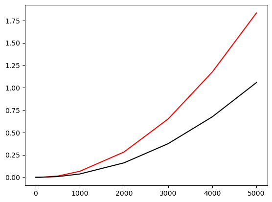

```python
import matplotlib.pyplot as plt
import time
import random
%matplotlib inline

def bubble_sort(array):
    for i in range(0, len(array)):
        for j in range(0, len(array) - i -1):
            if array[j] > array[j+1]:
                array[j], array[j+1] = array[j+1], array[j]

def insertion_sort(nums):
    for j in range(1, len(nums)):
        key = nums[j]
        i = j - 1
        while i >= 0 and nums[i] > key:
            nums[i + 1] = nums[i]
            i -= 1
        nums[i + 1] = key

sizes = [5, 10, 50, 100, 500, 1000, 2000, 3000, 4000, 5000]
arrays = []
for size in sizes:
    array = [random.randint(0, 100) for _ in range(size)]
    arrays.append(array)

timeB = []
for n in range(len(sizes)):
    start_time = time.time()
    bubble_sort(arrays[n])
    timeB.append(time.time() - start_time)
timeI = []
for n in range(len(sizes)):
    start_time = time.time()
    bubble_sort(arrays[n])
    timeI.append(time.time() - start_time)

plt.plot([5, 10, 50, 100, 500, 1000, 2000, 3000, 4000, 5000], [timeB[0], timeB[1],timeB[2],timeB[3],timeB[4],timeB[5],timeB[6],timeB[7],timeB[8],timeB[9]], color='red')
plt.plot([5, 10, 50, 100, 500, 1000, 2000, 3000, 4000, 5000], [timeI[0], timeI[1],timeI[2],timeI[3],timeI[4],timeI[5],timeI[6],timeI[7],timeI[8],timeI[9]], color='black')
print("Червоною лінією зображено BubbleSort, чорною лінією InsertSort")
```

#### 7) Надати відповіді на контрольні запитання

1. Що таке O-нотація і чим вона відрізняється від Ω -нотації?

*O-нотація, використовується для показу асиптотичної складності алгоритму. O-нотація показує верхню межу часової складності алгоритму, а Ω - нижню*

2. Яку часову складність має алгоритм сортування методом вставляння за найсприятливіших умов, коли масив відсортовано? Відповідь обґрунтувати.

*За найспритливіших умов алгоритм методом вставляння має асимптотичну складність O(n), бо містить while p з умовою nums[i] > key, яка при nums[i] < key не виконуватиметься, позбуваючись цикла в циклі*

3. Надати визначення ефективного алгоритму.

*Ефективний алгоритм повинен бути з оптимальною часовою складністю для відповідної задачі. Повинен виконуватись швидко і досягати найкращого можливого результату*

4. Пояснити поняття головного параметра (розміру) завдання.

*Головний параметр завдання - це кількість елементів масиву, визначає розмір задачі, використовується для знаходження асимптотичної складності алгоритму*

5. Функція часової складності має вигляд:$ f(x) = n^3 + 7n^2 - 14n $ , Як записати асимптотичну складність у O-нотації?

*$ O(n^3) $ бо ми нехтуємо константами і значеннями менші за найбільший*